# END-TO-END ANALYTICS FOR CANCER MORTALITY

# Confusion Matrix of the predicted result showing 83 percent TP cases.

```
{'TN': np.int64(4), 'FP': np.int64(1), 'FN': np.int64(1), 'TP': np.int64(5)}
          Pred 0  Pred 1
Actual 0       4       1
Actual 1       1       5
```

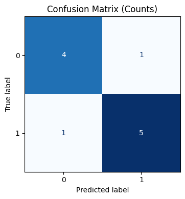

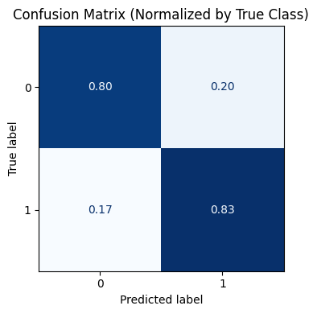

```
{'Accuracy': 0.818, 'Precision': 0.833, 'Recall': 0.833, 'F1': 0.833}
```

```python
from sklearn.metrics import confusion_matrix, ConfusionMatrixDisplay, accuracy_score, precision_score, recall_score, f1_score
import matplotlib.pyplot as plt
import pandas as pd

# If you already have predictions:
# y_pred = pipeline.predict(X_test)   # or model.predict(X_test)

# 1) Raw counts
cm = confusion_matrix(y_test, y_pred)
tn, fp, fn, tp = cm.ravel()
print({"TN": tn, "FP": fp, "FN": fn, "TP": tp})

# 2) Nice table (counts)
cm_tbl = pd.DataFrame(cm,
    index=["Actual 0", "Actual 1"],
    columns=["Pred 0", "Pred 1"]
)
print(cm_tbl)

# 3) Matplotlib plot (counts)
fig, ax = plt.subplots(figsize=(4,4))
disp = ConfusionMatrixDisplay(confusion_matrix=cm, display_labels=[0,1])
disp.plot(ax=ax, cmap="Blues", values_format="d", colorbar=False)
ax.set_title("Confusion Matrix (Counts)")
plt.tight_layout()
plt.show()

# 4) Normalized version (rates by true class)
cm_norm = confusion_matrix(y_test, y_pred, normalize="true")
fig, ax = plt.subplots(figsize=(4,4))
disp = ConfusionMatrixDisplay(confusion_matrix=cm_norm, display_labels=[0,1])
disp.plot(ax=ax, cmap="Blues", values_format=".2f", colorbar=False)
ax.set_title("Confusion Matrix (Normalized by True Class)")
plt.tight_layout()
plt.show()

# (Optional) quick metrics for the slide footer
print({
    "Accuracy": round(accuracy_score(y_test, y_pred), 3),
    "Precision": round(precision_score(y_test, y_pred), 3),
    "Recall": round(recall_score(y_test, y_pred), 3),
    "F1": round(f1_score(y_test, y_pred), 3),
})
```

We got almost the same prediction accuracy 81% with both Logistic and Random forest model showcasing liniearity in data  
Furthermore we found Consuming one or more fruits, Cigratte use and BMI had major importance in determining cancer death result.

Our EDA established a clean, state-level table with 51 complete observations across 24 numeric indicators spanning social determinants (fruit/vegetable intake, smoking, BMI, screening, physical activity), demographics (age structure, education, ethnicity) metrics; all listed columns show 51 non-null values, confirming no missingness, with numeric datatype for features, making the dataset tidy and modeling-ready.

Because death rates were reported per 100,000, we also converted numeric death-rate fields to a per-1,000 scale to keep magnitudes intuitive and comparable across analyses.

For prediction, we framed a supervised task by binarizing the outcome at the mean (above-mean = 1, below-mean = 0), then explicitly dropped all raw death-rate columns from the features to prevent leakage before modeling—a small but crucial detail to preserve honest generalization.

A baseline Random Forest within a preprocessing pipeline achieved ~81.8% accuracy on held-out predictions, and a logistic regression baseline reached a nearly identical score (~81%), suggesting largely linear separability with modest non-linear gains—useful for stakeholders seeking interpretable, stable rules without major performance trade-offs.

INSIGHTS:  
The forest’s feature-importance profile aligns with public-health priors and the EDA:  
The most influential predictors included Under 66 with a disability (~0.109), Consumed 1+ fruits/day (~0.091), Healthy-weight BMI (~0.073), Adult smokers (~0.073), and Hispanic ethnicity (~0.073), with smaller weights distributed across education, poverty, and internet access—together sketching a socio-behavioral and access-to-care footprint linked to mortality risk.

Interpreting these pieces together:  
(1) the EDA shows a well-structured, comprehensive panel of behavioral and demographic indicators available for every state.  
(2) inferential testing confirms meaningful geographic (regional) differences in mortality rates beyond noise.  
(3) the ML layer highlights actionable levers—tobacco exposure, diet quality, body-weight distribution and disability context—that can help prioritize interventions and tailor outreach.

Practically, this means public-health planners can use regional findings to target resources at high-risk areas and leverage the importance profile to choose specific, measurable program levers (e.g., smoking cessation, produce access, preventive-care navigation in diverse communities), while the parity between logistic and random-forest performance offers flexibility: deploy a simple, transparent logistic model for policy communication, or keep the random forest model for robustness without sacrificing interpretability provided by ranked importances.